# JOUR8500 Week06 - Text2Vec

Eunsun, Jikai, Qiling (based on Alvin’s code)

2026-02-23

## Overview

Today we will learn something about text2vec, including: (1) A basic introduction about what text2vec is and some basic parts of its mechanism; (2) some common pre-trained embedding (e.g., glove) and ways to load them (step 2-4); (3) some functions that we can see to look into the relationship between different words, like find similar words (step 5), compute analogies (step 6), and compute similarity between two words (step 7), and finally, the (4) visualization part (Step 8).

## Introduction

Text2vec is an approach that maps words in natural language to numerical vector representations that can be processed by computers. A vector can be understood as a point in an n-dimensional space. For example, in a one-dimensional space, a vector can be represented by a single number, while in a two-dimensional space, it can be represented by two numbers, such as (x, y). Similarly, in higher-dimensional spaces, a vector consists of more numbers.

## Step 0: Set working directory

Everything starts from here! Set the working directory you want!

```r
#setwd()
```

## Step 1: Install required packages

`tidyverse` is what we learned from previous classes. `text2vec`is the core package we need in today’s class. It transfers words into vectors. `Rtsne` is used for reducing dimensions. `ggplot` is used for visualization

```r
if (!require("tidyverse")) install.packages("tidyverse")
if (!require("text2vec")) install.packages("text2vec")
if (!require("Rtsne")) install.packages("Rtsne")
if (!require("ggplot2")) install.packages("ggplot2")
```

## Step 2: Download pre-trained GloVe embedding (glove.twitter.27B.100d.txt)

`embedding` is a technique that represents words as vectors in a high-dimensional space, enabling computers to capture semantic relationships between words and machines should learn it from a large corpus.

`Pre-trained embedding` is the embedding already trained based on certain corpus.

Common pre-trained embedding includes GloVe embedding, Google embedding, etc. In this example, we will use GloVe.twitter.27B.100d.

Here is the way to download it: source: https://nlp.stanford.edu/projects/glove/ kaggle link: https://www.kaggle.com/datasets/bertcarremans/glovetwitter27b100dtxt?resource=download Download the zip file Then extract it

## Step 3: Load pre-trained GloVe vectors into R

For pre-trained embedding, there may be different data formats. Let’s use .txt format this time.

```r
# Load the GloVe 100-dimensional embedding
glove_embeddings <- read_delim("glove.twitter.27B.100d.txt",
                               delim = " ", quote = "", col_names = FALSE)
# The first column is the word, the rest are vector values
word_vectors <- as.matrix(glove_embeddings[, -1])
rownames(word_vectors) <- glove_embeddings[[1]]
# You now have a word embedding matrix: rows = words, columns = dimensions
```

## Step 4: Explore the loaded model

Let’s figure out how many words and dimensions do we have, and get a sample of 50 words.

```r
# How many words and dimensions
# You have 1193514 words, each word is represented by a 100-dimensional vector (i.e., 100 numbers)
print(dim(word_vectors))
```

```
## [1] 1193514     100
```

```r
# View a random sample of 50 words in the embedding
sample(rownames(word_vectors), 50)
```

```
##  [1] "mood?nn"
##  [2] "brmksud"
##  [3] "関ジャニの仕分け"
##  [4] "بتركها"
##  [5] "dağıtıp"
##  [6] "decaprio"
##  [7] "حّـَلاۈة"
##  [8] "kuttu"
##  [9] "n最後まで彼女の事考えてたんかなn皆は命捨てれるほどの大切な人いる"
## [10] "上下セット"
## [11] "victoor"
## [12] "libertario"
## [13] "إلتقى"
## [14] "نسوني"
## [15] "sumbat"
```

[output cut: 35 more lines]

## Step 5: Find similar words

Example 1: words similar to “king”

```r
king_vec <- word_vectors["king", , drop = FALSE]
# Compute "King"'s cosine similarity with other words
similar_words <- sim2(word_vectors, king_vec, method = "cosine", norm = "l2")
# Sort by similarity and show top 10 similar words
head(sort(similar_words[,1], decreasing = TRUE), 10)
```

```
##      king    prince       aka     queen       the       mr.    legend        's
## 1.0000000 0.7755852 0.7499573 0.7075934 0.6970062 0.6886697 0.6823233 0.6767037
##     kings      jack
## 0.6758019 0.6584788
```

Example 2: words similar to “happy”

```r
happy_vec <- word_vectors["happy", , drop = FALSE]
# Compute "happy"'s cosine similarity with other words
similar_words <- sim2(word_vectors, happy_vec, method = "cosine", norm = "l2")
# Sort by similarity and show top 10 similar words
head(sort(similar_words[,1], decreasing = TRUE), 10)
```

```
##     happy  birthday       day      bday     merry      love      wish      hope
## 1.0000000 0.9259342 0.8549739 0.8145428 0.7886534 0.7855905 0.7771798 0.7660957
##     thank      year
## 0.7639738 0.7505834
```

Example 3: words similar to “democrat”

```r
democrat_vec <- word_vectors["democrat", , drop = FALSE]
# Compute "democrat"'s cosine similarity with other words
similar_words <- sim2(word_vectors, democrat_vec, method = "cosine", norm = "l2")
# Sort by similarity and show top 10 similar words
head(sort(similar_words[,1], decreasing = TRUE), 10)
```

```
##     democrat   republican   democratic conservative          gop    democrats
##    1.0000000    0.9220445    0.8064648    0.7778613    0.7762668    0.7751633
##  republicans  libertarian      senator   politician
##    0.7670569    0.7654968    0.7645831    0.7516647
```

## Step 6: Compute analogies

Word algebra: king - man + woman ≈ queen Explanation: Each word is represented as a vector in a high-dimensional semantic space. By subtracting “man” from “king”, we remove the “male” component,leaving the “royalty” concept. Then, by adding “woman”, we introduce the “female” component. The resulting vector should be closest to words representing a female royal role, such as “queen”.

```r
analogy_vec <- word_vectors["king", ] - word_vectors["man", ] + word_vectors["woman", ]
analogy_result <- sim2(word_vectors, matrix(analogy_vec, nrow = 1), method = "cosine", norm = "l2")
# Show the top 10 most similar words
# If the embedding captures semantic relationships well,
# "queen" should appear among the top results.
head(sort(analogy_result[,1], decreasing = TRUE), 10)
```

```
##      king     queen     woman    prince     royal    mother   african   goddess
## 0.6904542 0.6727578 0.6339608 0.6228977 0.6147280 0.6141974 0.5697248 0.5681217
##  princess     meets
## 0.5649643 0.5601145
```

Word algebra 2: puppy - dog + cat ≈ kitten Explanation: This captures the young-of relationship. “puppy” is a young dog, so applying the same relationship to “cat” should lead to “kitten”, which is a young cat.

```r
analogy_vec <- word_vectors["puppy", ] - word_vectors["dog", ] + word_vectors["cat", ]
analogy_res <- sim2(word_vectors, matrix(analogy_vec, nrow = 1), method = "cosine", norm = "l2")
head(sort(analogy_res[,1], decreasing = TRUE), 10)
```

```
##     puppy    kitten       cat     kitty       pup       pug   puppies   penguin
## 0.8683486 0.8612878 0.8137200 0.8010408 0.7571739 0.7122047 0.7121789 0.6946170
##   kittens     teddy
## 0.6857414 0.6738618
```

More analogies (some of them might not be perfect)

```r
analogy_vec <- word_vectors["guy", ] - word_vectors["man", ] + word_vectors["woman", ]
print(head(sort(sim2(word_vectors, matrix(analogy_vec, nrow = 1), method = "cosine")[,1], decreasing = TRUE), 10))
```

```
##     woman       guy      girl    thinks     tells    female      wife    person
## 0.8204678 0.7652870 0.7183294 0.6890576 0.6866369 0.6851516 0.6833428 0.6816110
##    mother  daughter
## 0.6754062 0.6670493
```

```r
analogy_vec <- word_vectors["china", ] - word_vectors["beijing", ] + word_vectors["tokyo", ]
print(head(sort(sim2(word_vectors, matrix(analogy_vec, nrow = 1), method = "cosine")[,1], decreasing = TRUE), 10))
```

```
##     china     tokyo     japan      asia   america      york     yahoo     world
## 0.7634586 0.6953512 0.6680392 0.6133405 0.5996178 0.5975124 0.5829204 0.5786165
##  american     india
## 0.5738388 0.5720680
```

```r
analogy_vec <- word_vectors["tokyo", ] - word_vectors["japan", ] + word_vectors["germany", ]
print(head(sort(sim2(word_vectors, matrix(analogy_vec, nrow = 1), method = "cosine")[,1], decreasing = TRUE), 10))
```

```
##   germany   austria    berlin     spain   denmark     basel melbourne   hamburg
## 0.7975197 0.7382410 0.7321208 0.7316566 0.7027211 0.7005492 0.6961597 0.6883476
##     italy   belgium
## 0.6852564 0.6787324
```

## Step 7: Compute similarity between two words

Example 1: Compare semantic similarity between “beijing”, “china”, and “chair” Cosine similarity measures how close two word vectors are in meaning. A higher value means the words appear in more similar contexts and have more similar meanings.

```r
sim2(word_vectors["beijing", , drop = FALSE],
     word_vectors["china", , drop = FALSE],
     method = "cosine")
```

```
##             china
## beijing 0.6040983
```

```r
sim2(word_vectors["beijing", , drop = FALSE],
     word_vectors["chair", , drop = FALSE],
     method = "cosine")
```

```
##             chair
## beijing 0.1357929
```

You can see that “beijing” is more similar to “china” than to “chair” Interpretation: “beijing” and “china” have a higher similarity score because they are semantically related (Beijing is the capital of China). “beijing” and “chair” have a lower similarity because they are unrelated concepts.

Example 2 (cute example): Compare “dog”, “cat”, and “table” This example is easier to understand because dogs and cats are both animals, while a table is an unrelated object.

```r
sim2(word_vectors["dog", , drop = FALSE],
     word_vectors["cat", , drop = FALSE],
     method = "cosine")
```

```
##          cat
## dog 0.875209
```

```r
sim2(word_vectors["dog", , drop = FALSE],
     word_vectors["table", , drop = FALSE],
     method = "cosine")
```

```
##         table
## dog 0.4302223
```

you can see that “dog” is more similar to “cat” than to “table” Interpretation: “dog” and “cat” should have a higher similarity score because they are both animals and appear in similar contexts. “dog” and “table” should have a lower similarity score because they are unrelated.

## Step 8: Visualize word embeddings with t-SNE

Pick some words to visualize 1

```r
words_to_plot <- c("king", "prince", "queen", "legend",
                   "jack", "happy", "china", "beijing", "japan")
```

Extract their vectors

```r
word_matrix <- word_vectors[words_to_plot, ]
```

You can print out the matrix to see the vectors

```r
print(word_matrix)
```

```
##                X2        X3        X4        X5        X6        X7        X8
## king    -0.375000 -0.275320  0.124890 -0.092143 -0.431040  0.025268 -0.041867
## prince  -0.315950 -0.029257 -0.340350  0.020055 -0.505090 -0.170460  0.552460
## queen   -1.094400 -0.114790  0.145940  0.308050 -0.448810 -0.148970  0.228710
## legend  -0.169190 -0.249030  0.358730 -0.593330 -0.514350  0.100560 -0.448690
## jack     0.105280 -0.348260  0.210090 -0.382290 -0.599540 -0.127720  0.302160
## happy    0.023098 -0.110980  0.079839  0.265660  0.230830 -0.146830  0.290090
## china    0.287900 -0.223880  0.144960 -0.096687 -0.364640 -0.016840  0.089967
## beijing -0.199530  0.331650  0.536070 -0.343680  0.031525  0.116940 -0.297830
## japan    0.297200 -0.155040  0.030370 -0.376220 -0.298920  0.081384  0.431460
##               X9       X10      X11      X12       X13     X14       X15
## king     0.12848 -0.079363 -0.10011  0.14076  0.109220 -3.4546 -0.698510
## prince  -0.18668 -0.422560 -0.14267 -0.20898 -0.002099 -2.8903 -0.328170
## queen    0.22399 -0.062934 -0.48477 -0.38805  0.184570 -2.9802 -1.031900
## legend   0.36304  0.079221  0.13315  0.32042  0.140260 -2.9942 -0.032869
## jack     0.15488 -0.269600  0.53728  0.32080  0.277390 -2.7622 -0.689380
## happy    0.24811 -0.387420  0.11899 -0.81393 -0.691970 -4.0274 -0.096299
## china   -0.16578  1.078100 -0.68464  0.35164  0.010059 -2.6871 -0.120340
## beijing -0.27100  0.173810 -0.88353  0.14563 -0.526880 -1.6411 -0.049029
## japan    0.24682  0.691570 -1.12090  0.34334 -0.166310 -2.8404 -0.120370
##               X16       X17       X18       X19       X20       X21      X22
## king     0.665800  0.514940  0.459120 -0.219570  0.440940 -0.306310  0.12293
## prince   0.576750  0.307740  0.529490 -0.137610  0.043182 -0.277120  0.38419
## queen    0.384460  0.876280  0.513750 -0.348140 -0.228360 -0.097192  0.25957
## legend   0.768410  0.010699  0.552700 -0.076427  0.658300  0.614380  0.33160
## jack    -0.091071 -0.021985  0.573440 -0.188930  0.133200 -0.026893  0.12809
## happy   -0.492730  0.711790  0.043593  0.048169 -0.902470  0.237040  0.20754
## china    0.558510  0.064739 -0.107500 -0.178370  0.464530 -1.037000 -0.36940
## beijing  0.645670 -0.793550 -0.188320 -1.103600 -0.021091 -0.773880 -0.37953
## japan    0.174920 -0.489000  0.013696  0.032679 -0.021386 -0.899670 -0.15080
##               X23       X24      X25       X26       X27       X28       X29
## king    -0.099830 -0.257550 -0.61872 1.0613000 -0.942780  0.192840 -0.082089
## prince  -0.925150  0.132310 -0.74533 0.8592900 -0.692480  0.023407  0.017133
## queen    0.039320 -0.073273  0.10547 0.8907400 -0.963390  0.419670  0.436880
## legend   0.065111  0.652780 -1.07840 0.3935800 -0.119610  0.213600 -0.110000
## jack    -0.580030  0.230370 -0.19972 0.0071467 -1.068300  0.212790  0.369890
## happy   -0.108220 -0.690710 -0.33782 0.8358400 -0.750440  0.219050  0.286620
## china   -0.802700  0.241230  0.46836 0.2883300 -1.386100  0.136510 -0.061628
## beijing -0.403280  0.412720  0.34304 0.8641500  0.054855 -0.344420 -0.240380
## japan   -0.450470  0.976850  0.69023 0.7436200  0.322180  0.270600 -0.428190
```

[output cut: 95 more lines]

```
## jack     0.046601 -0.50006 -0.73338  0.25920  0.078612  0.463070  0.069251
## happy    0.485880 -0.49273  0.46741  0.37783  0.553840 -0.101000 -0.392500
## china   -0.268230 -0.18330  0.48061 -0.61345  0.470780 -0.179740 -0.320460
## beijing  0.256840 -0.13417  0.18665 -0.74023  0.241260  0.066801 -0.491520
## japan   -0.246120  0.14905  0.55141 -0.49453 -0.025276  0.186800  0.193210
##              X99        X100      X101
## king     0.46786 -0.23716000  0.024995
## prince   0.40251 -0.53253000  0.454470
## queen    0.28488 -0.42374000 -0.640820
## legend   0.58705 -0.00011685 -0.133500
## jack    -0.23532 -0.49130000 -0.051582
## happy    0.11309 -0.16130000 -1.018400
## china   -0.32507 -0.39196000 -0.278630
## beijing -0.62094 -0.76153000  0.336280
## japan   -0.60300  0.19737000  0.263770
```

Run t-SNE (dimensionality reduction to 2D)

```r
tsne_result <- Rtsne(word_matrix, dims = 2, perplexity = 2)
```

Create data frame for plotting

```r
tsne_df <- data.frame(x = tsne_result$Y[,1],
                      y = tsne_result$Y[,2],
                      word = words_to_plot)
```

Plot using ggplot2

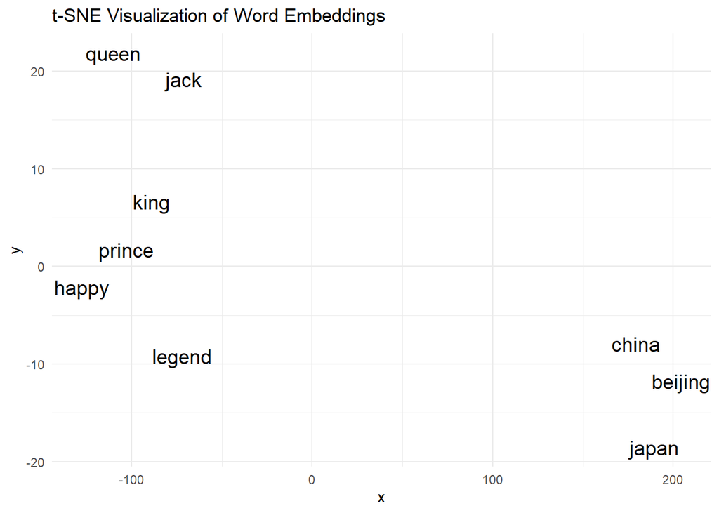

```r
ggplot(tsne_df, aes(x = x, y = y, label = word)) +
  geom_text(size = 5) +
  ggtitle("t-SNE Visualization of Word Embeddings") +
  theme_minimal()
```

Pick some words to visualize 2 Question 1: use words happy, birthday, puppy, kitten, love, hope, king, jack, legend, prince and visualize word embeddings with t-SNE Answer:

```r
words_to_plot <- c("happy", "birthday", "puppy", "kitten", "love",
                   "hope", "king", "jack", "legend", "prince" )

word_matrix <- word_vectors[words_to_plot, ]

print(word_matrix)
```

```
##                 X2        X3        X4        X5       X6        X7        X8
## happy     0.023098 -0.110980  0.079839  0.265660  0.23083 -0.146830  0.290090
## birthday -0.177600  0.203500  0.167860  0.355650  0.35002 -0.571800  0.178260
## puppy     0.244570 -0.635890  0.889710  0.348960  0.19479 -1.069000  0.956070
## kitten    0.399130 -0.429720  0.063241  0.969980 -0.24312 -0.686310  0.625000
## love     -0.483710 -0.273180 -0.046840  0.702740 -0.56301 -0.172140  0.817750
## hope      0.096828  0.962160  0.266310  0.174500 -0.37467  0.263760  0.498620
## king     -0.375000 -0.275320  0.124890 -0.092143 -0.43104  0.025268 -0.041867
## jack      0.105280 -0.348260  0.210090 -0.382290 -0.59954 -0.127720  0.302160
## legend   -0.169190 -0.249030  0.358730 -0.593330 -0.51435  0.100560 -0.448690
## prince   -0.315950 -0.029257 -0.340350  0.020055 -0.50509 -0.170460  0.552460
##                 X9       X10       X11       X12       X13     X14       X15
## happy     0.248110 -0.387420  0.118990 -0.813930 -0.691970 -4.0274 -0.096299
## birthday  0.475500 -0.634890 -0.021838 -1.170900  0.014577 -3.5981 -0.474350
## puppy    -0.196220  0.354550 -0.282680 -0.745880  0.326640 -2.5444  0.569490
## kitten   -0.809520  0.342330 -0.776180 -0.589190  0.495380 -1.9928  0.399920
## love     -0.066641  0.020224 -0.238780 -0.016122 -0.178750 -4.9281 -0.402720
## hope     -0.074503  0.105880  0.275780 -0.102560  0.169230 -4.7434  0.417100
## king      0.128480 -0.079363 -0.100110  0.140760  0.109220 -3.4546 -0.698510
## jack      0.154880 -0.269600  0.537280  0.320800  0.277390 -2.7622 -0.689380
## legend    0.363040  0.079221  0.133150  0.320420  0.140260 -2.9942 -0.032869
## prince   -0.186680 -0.422560 -0.142670 -0.208980 -0.002099 -2.8903 -0.328170
##                X16       X17      X18       X19       X20       X21       X22
## happy    -0.492730  0.711790 0.043593  0.048169 -0.902470  0.237040 0.2075400
## birthday -0.067190  0.607900 0.031857  0.087077 -0.804330  0.105610 0.2261300
## puppy     0.254280  0.392410 0.268700  0.542040 -0.722380 -0.697500 0.0479720
## kitten    0.071024  0.690270 0.499250  0.276570 -0.518290 -0.740430 0.0008219
## love     -0.411900 -0.145700 0.185080 -0.191160 -0.846080  0.653780 0.1237000
## hope      0.086999  0.031635 0.334800 -0.172570 -0.516000  0.017930 0.2473900
## king      0.665800  0.514940 0.459120 -0.219570  0.440940 -0.306310 0.1229300
## jack     -0.091071 -0.021985 0.573440 -0.188930  0.133200 -0.026893 0.1280900
## legend    0.768410  0.010699 0.552700 -0.076427  0.658300  0.614380 0.3316000
## prince    0.576750  0.307740 0.529490 -0.137610  0.043182 -0.277120 0.3841900
##                X23      X24      X25       X26       X27       X28       X29
## happy    -0.108220 -0.69071 -0.33782 0.8358400 -0.750440  0.219050  0.286620
## birthday -0.240510 -0.50650 -0.37797 0.8746900 -0.855580  0.409220 -0.023243
## puppy     0.207680 -0.66447  0.16990 0.6377800  0.437420 -0.628860  0.417880
## kitten    0.205420 -0.40354 -0.19169 0.2639200  0.703820 -0.591260  0.519310
## love      0.048835 -0.33709  0.25834 0.4772900 -0.881450 -0.130830  0.794990
## hope     -0.350230 -0.18885  0.20731 0.0752280  0.041435  0.275580  0.119400
```

[output cut: 110 more lines]

```
## king      0.0038808 0.654860 -0.596100 -0.458930 -0.43281  0.072713  0.650280
## jack      0.6828600 0.046601 -0.500060 -0.733380  0.25920  0.078612  0.463070
## legend    0.1390200 0.684630 -0.289820 -0.417600 -0.54734 -0.361900  0.464860
## prince    0.3719700 1.059800 -0.571790 -0.782450  0.43919 -0.172990  0.347440
##                X98       X99        X100      X101
## happy    -0.392500  0.113090 -0.16130000 -1.018400
## birthday -0.542380  0.267230 -0.17317000 -0.950140
## puppy    -0.187670  0.286980  0.08551000  1.124100
## kitten   -0.415600  0.621450  0.28217000  0.585680
## love     -0.185010 -0.329920  0.27373000 -0.154160
## hope      0.149690  0.073275  0.15363000 -0.449240
## king      0.059122  0.467860 -0.23716000  0.024995
## jack      0.069251 -0.235320 -0.49130000 -0.051582
## legend    0.922950  0.587050 -0.00011685 -0.133500
## prince    0.486200  0.402510 -0.53253000  0.454470
```

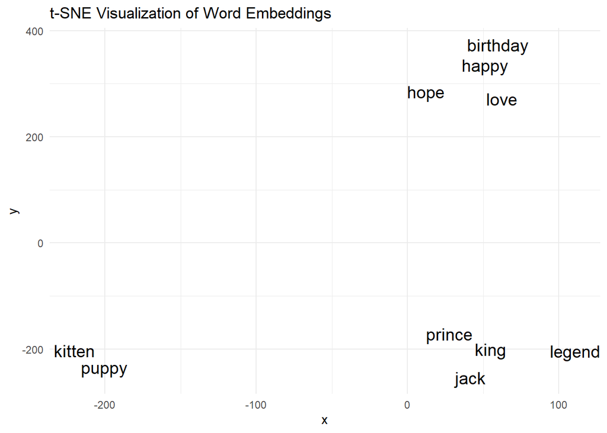

```r
tsne_result <- Rtsne(word_matrix, dims = 2, perplexity = 2)

tsne_df <- data.frame(x = tsne_result$Y[,1],
                      y = tsne_result$Y[,2],
                      word = words_to_plot)

ggplot(tsne_df, aes(x = x, y = y, label = word)) +
  geom_text(size = 5) +
  ggtitle("t-SNE Visualization of Word Embeddings") +
  theme_minimal()
```

Pick some words to visualize 3 Question 2: use words puppy, kitten, kitty, hope, king, prince,queen, democrat, republican, politician, happy, love Answer:

```r
words_to_plot <- c("puppy", "kitten", "kitty",
                   "hope", "king", "prince","queen",
                   "democrat", "republican", "politician",
                   "happy", "love")

word_matrix <- word_vectors[words_to_plot, ]

print(word_matrix)
```

```
##                   X2        X3        X4        X5        X6        X7
## puppy       0.244570 -0.635890  0.889710  0.348960  0.194790 -1.069000
## kitten      0.399130 -0.429720  0.063241  0.969980 -0.243120 -0.686310
## kitty       0.387980 -0.449520 -0.283700  0.692770  0.063659 -0.441270
## hope        0.096828  0.962160  0.266310  0.174500 -0.374670  0.263760
## king       -0.375000 -0.275320  0.124890 -0.092143 -0.431040  0.025268
## prince     -0.315950 -0.029257 -0.340350  0.020055 -0.505090 -0.170460
## queen      -1.094400 -0.114790  0.145940  0.308050 -0.448810 -0.148970
## democrat   -0.609240  0.567640 -0.422430  0.540770  0.268780  0.412250
## republican -0.122250  0.847210 -0.070834  0.659730  0.205020  0.375940
## politician  0.154080  0.450400 -0.530020  0.798310 -0.085994  0.127690
## happy       0.023098 -0.110980  0.079839  0.265660  0.230830 -0.146830
## love       -0.483710 -0.273180 -0.046840  0.702740 -0.563010 -0.172140
##                   X8        X9       X10      X11       X12       X13     X14
## puppy       0.956070 -0.196220  0.354550 -0.28268 -0.745880  0.326640 -2.5444
## kitten      0.625000 -0.809520  0.342330 -0.77618 -0.589190  0.495380 -1.9928
## kitty       0.711000 -0.116620  0.251430 -0.33032 -0.380450  1.057100 -2.2386
## hope        0.498620 -0.074503  0.105880  0.27578 -0.102560  0.169230 -4.7434
## king       -0.041867  0.128480 -0.079363 -0.10011  0.140760  0.109220 -3.4546
## prince      0.552460 -0.186680 -0.422560 -0.14267 -0.208980 -0.002099 -2.8903
## queen       0.228710  0.223990 -0.062934 -0.48477 -0.388050  0.184570 -2.9802
## democrat    0.330770 -0.142510 -0.434020 -0.79033 -0.504430 -0.836110 -1.5462
## republican  0.261950  0.278570 -0.282180 -0.64059 -0.252590 -1.041600 -2.0283
## politician -0.045737 -0.408820  0.073632 -0.66432 -0.253470 -0.921560 -2.1408
## happy       0.290090  0.248110 -0.387420  0.11899 -0.813930 -0.691970 -4.0274
## love        0.817750 -0.066641  0.020224 -0.23878 -0.016122 -0.178750 -4.9281
##                  X15       X16       X17       X18       X19        X20
## puppy       0.569490  0.254280  0.392410  0.268700  0.542040 -0.7223800
## kitten      0.399920  0.071024  0.690270  0.499250  0.276570 -0.5182900
## kitty      -0.170200  0.012685  1.220300  0.275320  0.351170 -0.2334500
## hope        0.417100  0.086999  0.031635  0.334800 -0.172570 -0.5160000
## king       -0.698510  0.665800  0.514940  0.459120 -0.219570  0.4409400
## prince     -0.328170  0.576750  0.307740  0.529490 -0.137610  0.0431820
## queen      -1.031900  0.384460  0.876280  0.513750 -0.348140 -0.2283600
## democrat    0.295520  0.410600 -0.036304 -0.215720 -0.448760  0.3785000
## republican -0.034209  0.888030  0.213670 -0.456290 -0.895800 -0.0088416
## politician  0.283300  0.439070 -0.458620  0.276670 -0.398550  0.0921020
## happy      -0.096299 -0.492730  0.711790  0.043593  0.048169 -0.9024700
## love       -0.402720 -0.411900 -0.145700  0.185080 -0.191160 -0.8460800
##                  X21        X22       X23       X24      X25       X26
```

[output cut: 153 more lines]

```
## happy       0.105160  0.0347890  0.485880 -0.492730  0.467410  0.37783
## love        0.083593  0.1323700  0.885980  0.288760 -0.071663  0.33424
##                  X96       X97       X98       X99       X100      X101
## puppy       0.704870  0.320750 -0.187670  0.286980  0.0855100  1.124100
## kitten      0.163270  0.076806 -0.415600  0.621450  0.2821700  0.585680
## kitty       0.195130  0.089207 -0.227670  0.024699 -0.4673000  0.499920
## hope       -0.407490 -0.332900  0.149690  0.073275  0.1536300 -0.449240
## king        0.072713  0.650280  0.059122  0.467860 -0.2371600  0.024995
## prince     -0.172990  0.347440  0.486200  0.402510 -0.5325300  0.454470
## queen      -0.653890  0.048717  0.155650  0.284880 -0.4237400 -0.640820
## democrat   -0.335090  0.291850 -0.108110  0.626440 -0.1618500 -0.133070
## republican -0.189710  0.226400 -0.403710  0.724660  0.0073691 -0.159620
## politician -0.071543  0.336130  0.645850  0.420560 -0.0890600  0.308460
## happy       0.553840 -0.101000 -0.392500  0.113090 -0.1613000 -1.018400
## love       -0.088094  0.041479 -0.185010 -0.329920  0.2737300 -0.154160
```

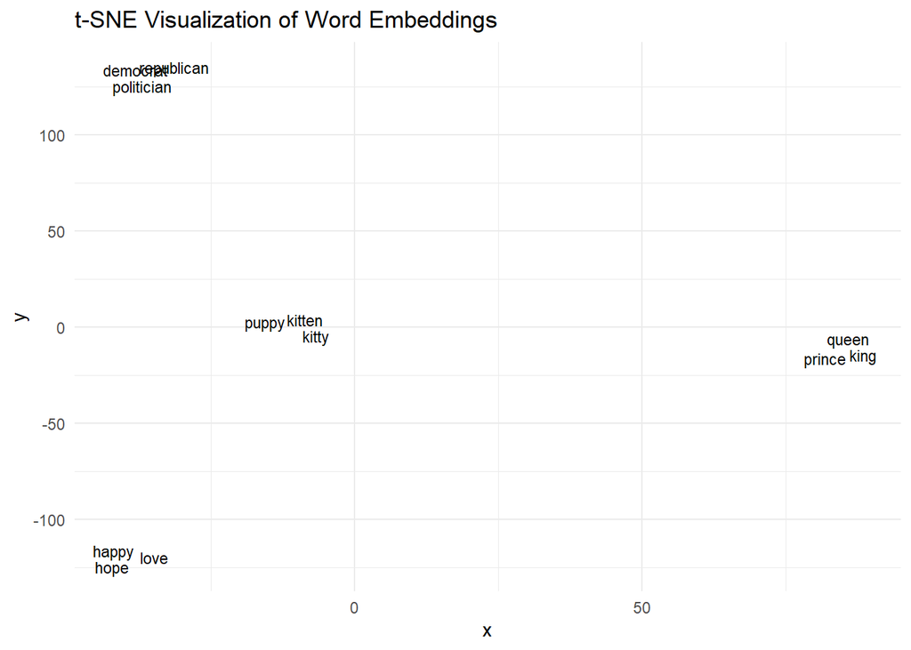

```r
tsne_result <- Rtsne(word_matrix, dims = 2, perplexity = 2)

tsne_df <- data.frame(x = tsne_result$Y[,1],
                      y = tsne_result$Y[,2],
                      word = words_to_plot)

ggplot(tsne_df, aes(x = x, y = y, label = word)) +
  geom_text(size = 3) +
  ggtitle("t-SNE Visualization of Word Embeddings") +
  theme_minimal()
```

Pick some words to visualize 4

```r
words_to_plot <- c("tokyo", "beijing", "chair", "china",
                   "guy", "japan", "man", "woman",
                   "germany", "cat", "dog","puppy",
                   "happy", "king", "democrat")
# Extract their vectors
word_matrix <- word_vectors[words_to_plot, ]
# You can print out the matrix to see the vectors
print(word_matrix)
```

```
##                 X2         X3        X4        X5          X6        X7
## tokyo     0.169210 -0.1096100 -0.196050 -0.371900 -0.53809000  0.161430
## beijing  -0.199530  0.3316500  0.536070 -0.343680  0.03152500  0.116940
## chair     0.130270 -0.1228700  0.628100 -0.104630 -0.05591000  0.277620
## china     0.287900 -0.2238800  0.144960 -0.096687 -0.36464000 -0.016840
## guy       0.645890  0.0083318  0.122440 -0.108280 -0.00077361 -0.185120
## japan     0.297200 -0.1550400  0.030370 -0.376220 -0.29892000  0.081384
## man       0.446990 -0.1084600 -0.379700  0.091906 -0.49038000  0.601790
## woman     0.357610 -0.5573700 -0.297620  0.560730 -0.39830000 -0.215510
## germany   0.193690  0.5071500  0.287390  0.131880 -0.28115000  0.644320
## cat       0.384460 -0.4550700  0.453510  0.430100 -0.05090800 -0.264140
## dog       0.507790 -1.0274000  0.481360 -0.094170  0.44837000 -0.522910
## puppy     0.244570 -0.6358900  0.889710  0.348960  0.19479000 -1.069000
## happy     0.023098 -0.1109800  0.079839  0.265660  0.23083000 -0.146830
## king     -0.375000 -0.2753200  0.124890 -0.092143 -0.43104000  0.025268
## democrat -0.609240  0.5676400 -0.422430  0.540770  0.26878000  0.412250
##                  X8        X9       X10        X11        X12       X13     X14
## tokyo    -0.1247200 -0.253270  0.217240 -0.4477300 -0.3373800  0.051271 -1.9254
## beijing  -0.2978300 -0.271000  0.173810 -0.8835300  0.1456300 -0.526880 -1.6411
## chair     0.5315300 -0.291020 -0.434570 -0.4086200 -0.1686900  0.959820 -2.5088
## china     0.0899670 -0.165780  1.078100 -0.6846400  0.3516400  0.010059 -2.6871
## guy       0.4537100  0.304150  0.014631 -0.3368300 -0.0050524  0.145920 -4.4830
## japan     0.4314600  0.246820  0.691570 -1.1209000  0.3433400 -0.166310 -2.8404
## man       0.0056179  0.746290  0.664780  0.0653190  0.1692100  0.589920 -4.2407
## woman     0.5980100  0.130160  0.603630 -0.4305000 -0.3259000  0.096317 -4.1119
## germany  -0.0052743 -0.140610  0.421810 -0.6549100  0.4736800 -0.108710 -3.0862
## cat       0.4325300 -0.316600  0.322140  0.0064333 -0.4706600  0.953350 -3.2063
## dog       0.5149800 -0.038927  0.358670 -0.0659940 -0.8288200  0.761790 -3.8030
## puppy     0.9560700 -0.196220  0.354550 -0.2826800 -0.7458800  0.326640 -2.5444
## happy     0.2900900  0.248110 -0.387420  0.1189900 -0.8139300 -0.691970 -4.0274
## king     -0.0418670  0.128480 -0.079363 -0.1001100  0.1407600  0.109220 -3.4546
## democrat  0.3307700 -0.142510 -0.434020 -0.7903300 -0.5044300 -0.836110 -1.5462
##                X15      X16        X17       X18       X19       X20       X21
## tokyo     0.080200 -0.12018 -0.1841100 -0.241290 -0.029985 -0.258940 -0.706110
## beijing  -0.049029  0.64567 -0.7935500 -0.188320 -1.103600 -0.021091 -0.773880
## chair     0.300700  0.12431  0.2341000 -0.536970 -0.003987 -0.961290 -0.213940
## china    -0.120340  0.55851  0.0647390 -0.107500 -0.178370  0.464530 -1.037000
## guy       0.225450  0.16335  0.2917300  0.507160 -0.529800 -0.156250  0.096218
## japan    -0.120370  0.17492 -0.4890000  0.013696  0.032679 -0.021386 -0.899670
## man      -0.027100  0.40518 -0.0076202  0.920230 -0.458190 -0.034881 -0.306590
```

[output cut: 185 more lines]

```
## tokyo    -0.473710  0.639870  0.102930 -0.5830600 -0.329440  0.0048706
## beijing   0.241260  0.066801 -0.491520 -0.6209400 -0.761530  0.3362800
## chair    -0.458560 -0.572230  0.157450 -0.2190700 -0.442690  0.4595500
## china     0.470780 -0.179740 -0.320460 -0.3250700 -0.391960 -0.2786300
## guy       0.141140  0.226020  0.351950 -0.5551000  0.055514  0.1767400
## japan    -0.025276  0.186800  0.193210 -0.6030000  0.197370  0.2637700
## man      -0.041508  0.153980  0.729100  0.1654700  0.597150 -0.1826200
## woman     0.164340  0.556510  0.268930 -0.2062000 -0.128880 -0.5098600
## germany  -0.246000 -0.161420  0.512700  0.0034812 -0.021684 -0.4325400
## cat       0.296940  0.149380  0.117540  0.1569900 -0.342720  0.2435000
## dog       0.391190  0.676590 -0.071224  0.1745800 -0.033406  0.7315200
## puppy     0.704870  0.320750 -0.187670  0.2869800  0.085510  1.1241000
## happy     0.553840 -0.101000 -0.392500  0.1130900 -0.161300 -1.0184000
## king      0.072713  0.650280  0.059122  0.4678600 -0.237160  0.0249950
## democrat -0.335090  0.291850 -0.108110  0.6264400 -0.161850 -0.1330700
```

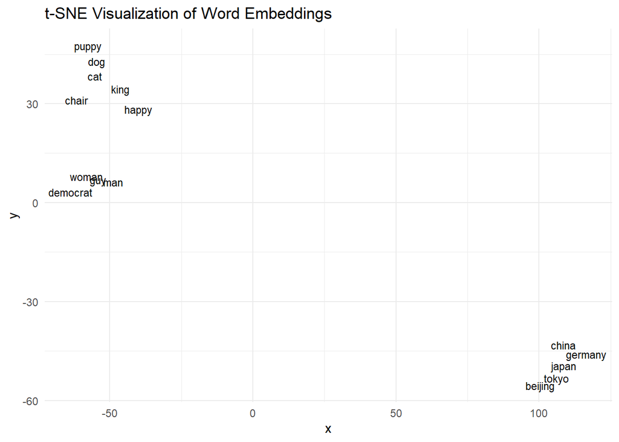

```r
# Run t-SNE (dimensionality reduction to 2D)
tsne_result <- Rtsne(word_matrix, dims = 2, perplexity = 2)
# Create data frame for plotting
tsne_df <- data.frame(x = tsne_result$Y[,1],
                      y = tsne_result$Y[,2],
                      word = words_to_plot)
# Plot using ggplot2
ggplot(tsne_df, aes(x = x, y = y, label = word)) +
  geom_text(size = 3) +
  ggtitle("t-SNE Visualization of Word Embeddings") +
  theme_minimal()
```